# Sage_Bratislava

- Sage
  - Introduction
  - Permutation Groups
  - Graphs
    - Common Graphs
    - Nowhere zero flow
  - Explorations in Algebraic Graph Theory with Sage
    - Cayley Graphs
  - Statistics </span>

# Introduction

SageMath is a free open-source mathematics software system licensed under the GPL. It builds on top of many existing open-source packages: NumPy, SciPy, matplotlib, Sympy, Maxima, GAP, FLINT, R and many more. Access their combined power through a common, Python-based language or directly via interfaces or wrappers.

for download: https://www.sagemath.org/download.html

https://www.sagemath.org/

http://gregorybard.com/Sage.html

```python
#<span style="font-size:1.2em;"> </span>
```

# Permutation groups

https://doc.sagemath.org/html/en/thematic_tutorials/group_theory.html#permutation-groups

A good portion of Sage’s support for group theory is based on routines from GAP (Groups, Algorithms, and Programming at https://www.gap-system.org. Groups can be described in many different ways, such as sets of matrices or sets of symbols subject to a few defining relations. A very concrete way to represent groups is via permutations (one-to-one and onto functions of the integers 1 through $n$), using function composition as the operation in the group. Sage has many routines designed to work with groups of this type and they are also a good way for those learning group theory to gain experience with the basic ideas of group theory. For both these reasons, we will concentrate on these types of groups.

# Writing permutations

Sage uses “disjoint cycle notation” for permutations, see any introductory text on group theory (such as Judson, Section 4.1) for more on this. Composition occurs left to right, which is not what you might expect and is exactly the reverse of what Judson and many others use. (There are good reasons to support either direction, you just need to be certain you know which one is in play.) There are two ways to write the permutation $\sigma=(13)(254)$:

- a text string (include quotes): "(1,3) (2,5,4)"
- As a Python list of “tuples”: [(1,3), (2,5,4)] </span>

```python
G = SymmetricGroup(5)
sigma = G("(1,3) (2,5,4)")
rho = G([(2,4), (1,5)])
rho^(-1) * sigma * rho
```

```
(1,2,4)(3,5)
```

```python
H = DihedralGroup(6)
H.list()
```

```
[(),
 (1,5,3)(2,6,4),
 (1,3,5)(2,4,6),
 (1,6,5,4,3,2),
 (1,4)(2,5)(3,6),
 (1,2,3,4,5,6),
 (2,6)(3,5),
 (1,5)(2,4),
 (1,3)(4,6),
 (1,6)(2,5)(3,4),
 (1,4)(2,3)(5,6),
 (1,2)(3,6)(4,5)]
```

```python
a = G.random_element()
H = G.subgroup([a])
gap.StructureDescription(H)
```

```
C6
```

will create $H$ as the cyclic subgroup of $G$ with generator $a$.

For example the code below will:

- create $G$ as the symmetric group on five symbols;
- specify sigma as an element of $G$;
- use sigma as the generator of a cyclic subgroup $H$;
- list all the elements of H.

In more mathematical notation, we might write $⟨(123)(45)⟩=H⊆G=S_5$.</span>

```python
G = SymmetricGroup(5)
sigma = G("(1,2,3) (4,5)")
H = G.subgroup([sigma])
H.list()
```

```
[(), (1,2,3)(4,5), (1,3,2), (4,5), (1,2,3), (1,3,2)(4,5)]
```

```python
H = gap.SmallGroup(256,5)
gap.StructureDescription(H)
```

```
((C8 x C2) : C4) : C4
```

```python
Elements(H)
```

```
Category of elements of Group( [ f1, f2, f3, f4, f5, f6, f7, f8 ] )
```

```python
A = gap.SmallGroup(27,4)
B = PermutationGroup(A.IsomorphismPermGroup().Image().GeneratorsOfGroup())
gap.StructureDescription(A)
```

```
C9 : C3
```

```python
Elements(B)
```

```
Category of elements of Permutation Group with generators [(1,2,5,4,7,12,10,15,20)(3,14,25,9,22,11,17,6,19)(8,26,24,16,13,27,23,21,18), (1,3,8)(2,6,13)(4,9,16)(5,11,18)(7,14,21)(10,17,23)(12,19,24)(15,22,26)(20,25,27), (1,4,10)(2,7,15)(3,9,17)(5,12,20)(6,14,22)(8,16,23)(11,19,25)(13,21,26)(18,24,27)…
```

# Graphs

(Common graphs) https://doc.sagemath.org/html/en/reference/graphs/sage/graphs/graph_generators.html

Combinatorial Data (Brendan McKay) https://users.cecs.anu.edu.au/~bdm/data/

Nauty http://users.cecs.anu.edu.au/~bdm/nauty/

vmadmin@vm1:~/sage-data/nauty27r1$ ./geng -c 10 -d4D4 ./c10_4_regular.txt

A ./geng -cd4D4 n=10 e=20

Z 59 graphs generated in 0.00 sec

```python
def energy(G):
    en = 0
    A = G.adjacency_matrix()
    for i in A.eigenvalues():
        en = en +abs(i)
    return en
```

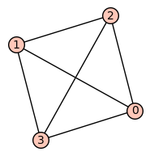

```python
fin = open("./graph4c.g6",'r')  #c10_4_regular.txt
for s in fin:
    G = Graph(s.strip(), format = 'graph6')
    if energy(G)==2*3:
        G.plot(figsize=[2,2]).show()
        save(G, 'H')
    #print(energy(G))
fin.close()
```

```python
# ![alt text](base_graph_384.png "Title")
# <img src="(base_graph_384.png" width="200"/>
```

[figure not shown]

| $O(\alpha_1)$ | $O(\alpha_2)$ | $O(\alpha_3)$ | $O(\alpha_4)$ | $O(\alpha_5)$ |
| --- | --- | --- | --- | --- |
| 8 | 4 | 12 | 8 | 12 |
| 8 | 12 | 4 | 8 | 12 |

```python
G22 = load('./G22.sobj')
G23 = load('./G23.sobj')
G22.is_isomorphic(G23)
```

```
True
```

```python
A22 = G22.automorphism_group()
A22.id()
```

```
[96, 123]
```

```python
A22.structure_description()
```

```
'C3 : ((C8 x C2) : C2)'
```

```python
g = graphs.PetersenGraph()
from sage.graphs.graph_coloring import vertex_coloring
vertex_coloring(g, value_only=True)
```

```
3
```

```python
vertex_coloring(g)
```

```
[[0, 2, 6], [3, 5, 9], [1, 4, 7, 8]]
```

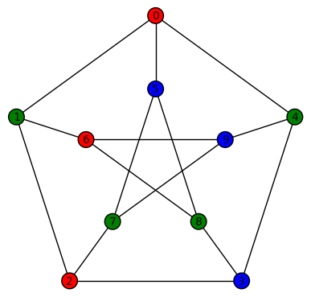

```python
d = {'r':[0, 2, 6],'b':[3, 5, 9],'g':[1, 4, 7, 8]}
g.graphplot(vertex_colors =d).show()
```

```python
from sage.graphs.graph_coloring import edge_coloring
edge_coloring(g, value_only=True)
```

```
4
```

```python
edge_coloring(g)
```

```
[[(0, 1), (2, 3), (4, 9), (5, 7), (6, 8)],
 [(0, 4), (1, 2), (3, 8), (6, 9)],
 [(0, 5), (2, 7)],
 [(1, 6), (3, 4), (5, 8), (7, 9)]]
```

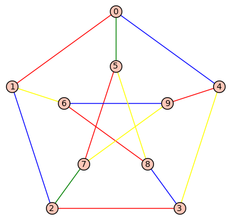

```python
d1 = {'red':[(0, 1), (2, 3), (4, 9), (5, 7), (6, 8)],'blue':[(0, 4), (1, 2), (3, 8), (6, 9)],'green':[(0, 5), (2, 7)],'yellow':[(1, 6), (3, 4), (5, 8), (7, 9)]}
g.graphplot(edge_colors =d1).show()
```

```
n = 10
longest path length = 10
```

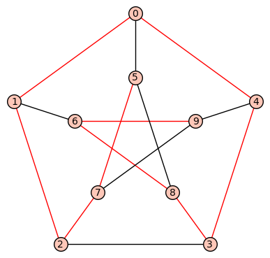

```python
longest = g.longest_path() # may also specify start- and endvertex
print("n =",g.num_verts())
print("longest path length =",len(longest))

g.show(edge_colors={"red": longest.edges(labels=False)})
```

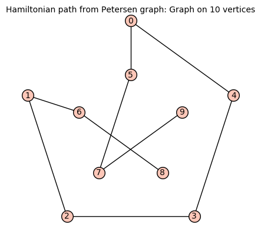

```python
g.hamiltonian_path()
```

```python
a = g.automorphism_group()
print(a)
gap.StructureDescription(a)
```

```
Permutation Group with generators [(3,7)(4,5)(8,9), (2,6)(3,8)(4,5)(7,9), (1,4,5)(2,3,8,6,9,7), (0,1)(2,4,6,5)(3,9,8,7)]
```

```
S5
```

```python
a.orbits()
```

```
[[0, 1, 4, 5, 6, 2, 9, 3, 8, 7]]
```

# Nowhere zero flow

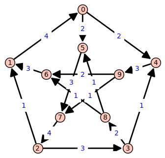

```python
g = graphs.PetersenGraph()
k = 5
h = g.nowhere_zero_flow(k)
pos = g.get_pos()
h.set_pos(pos)
h.show(edge_labels=True,figsize=5)
```

Tutte proved that a cubic graph $G$ has a nowhere-zero 3-flow if and only if $G$ is bipartite and that $G$ has a nowhere-zero 4-flow if and only if $G$ is a class 1 graph.

```python
k = 3
h = g.nowhere_zero_flow(k)
```

[output not shown]

```python
k = 4
h = g.nowhere_zero_flow(k)
```

[output not shown]

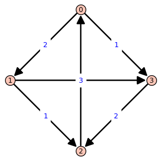

```python
g = graphs.CompleteGraph(4)
k = 4
h = g.nowhere_zero_flow(k)
pos = g.get_pos()
h.set_pos(pos)
h.show(edge_labels=True,figsize=5)
```

# Explorations in Algebraic Graph Theory with Sage

http://buzzard.pugetsound.edu/sage-practice/index.html

## Cayley Graphs

If G is a group and C⊆G (i.e., a list of some elements of G), then we can produce the Cayley graph X(G,C):

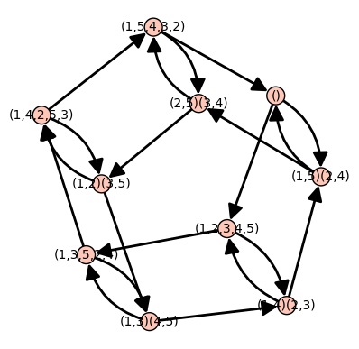

```python
G = DihedralGroup(5)
C = [G.gen(0), G.gen(1)]
CG = G.cayley_graph( generators = C)
CG.show()
```

The output is a directed graph, even if C is inverse-closed; in the latter case we can convert G to a graph by

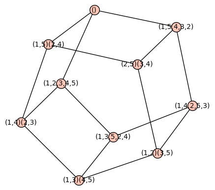

```python
CGU = CG.to_undirected()
CGU.show()
```

Note that the Graph() command makes it easy to construct Cayley graphs ourselves. For example, a cubelike graph is a Cayley graph for GF(2)d. We can construct them using Graph().

```python
def cubelike(d, vector_list):
    VS = VectorSpace(GF(2),d)
    vxs = range(2^d)
    return Graph([vxs, lambda i,j: VS[i]-VS[j] in vector_list])
```

Here vector_list is a list of 01-vectors of length $d$.

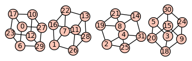

```python
V = GF(2)^5
vl = [V([0,1,1,0,0]), V([1,1,0,1,1]), V([1,0,0,0,1])]
T = cubelike(5, vl)
show(T, layout='circular')
```

For a general group, we can use the following construction to create an undirected Cayley graph.

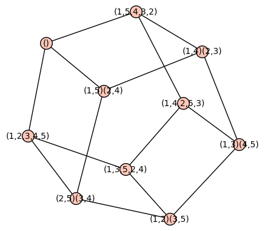

```python
G = DihedralGroup(5)
C = [G.gen(0), G.gen(0)^-1, G.gen(1), G.gen(1)^-1]
CG = Graph( [ G.list(), lambda g, h: h*g^(-1) in C])
CG.show()
```

This will produce an incorrect result if C is not inverse-closed.

[figure not shown]

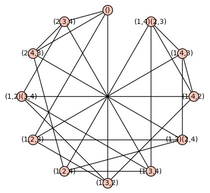

```python
H = AlternatingGroup(4)
a1 = H("(1,2,3)")
a2 = H("(1,3,2)")
a3 = H("(2,3,4)")
a4 = H("(2,4,3)")
C=[a1,a2,a3,a4]
CH = H.cayley_graph(generators = C)
#CH.show()
CHU = CH.to_undirected()
CHU.plot(layout='circular').show()
```

A layout algorithm – one of : “acyclic”, “circular” (plots the graph with vertices evenly distributed on a circle), “ranked”, “graphviz”, “planar”, “spring” (traditional spring layout, using the graph’s current positions as initial positions), or “tree” (the tree will be plotted in levels, depending on minimum distance for the root).

https://doc.sagemath.org/html/en/reference/plotting/sage/graphs/graph_plot.html

# Statistics

what is the expected of number of die rolls necessary to get 6?

```python
import random

a = []
for i in range(10000):
    n=1
    while(random.randint(1,6)!=6):
        n+=1
    a.append(n)
print(float(sum(a)/len(a)))
```

```
6.0045
```